# Estimating field metabolic rates using 3D stereo-video reveals the pace of life of coral reef fishes in the wild

First author: Francesca Conte*, Nina M. D. Schiettekatte* Contributing authors (alphabetic order): Simon J. Brandl, Beverly French, Chris Fulton, Alexandre Merciere, Tommy Norin, Valeriano Parravicini, Sébastien Villéger

## Introduction

Anthropogenic stressors such as intensive fishing and climate change are affecting fish communities at an unprecedented global scale. There is a growing concern that impoverished fish communities may not be able to sustain ecosystem functioning and provide the ecosystem services that are indispensable for human well-being (Cardinale et al., 2012). In order to take the pulse of the functioning of a community, it is essential to quantify key ecosystem processes on the individual level such as nutrient cycling, herbivory, predation, growth, etc (Brandl et al. 2019). Our ability to understand the role of fishes in a changing world hinges on our capacity to quantify the ecosystem processes of fishes in their natural environment.

The metabolic rate of living organisms is an essential determinant of the flow of energy and nutrients in any ecosystem (Brown et al. 2004; Allen et al. 2005). In aquatic systems, fishes contribute to a high proportion of the total consumer biomass and therefore are crucial actors in ecosystem functioning. Theory predicts that metabolic rate increases sub‐linearly with body mass according to a power function with a scaling coefficient of approximately 0.75 (Gillooly et al 2001; Brown et al 2004). This theoretic value has been widely accepted and confirmed for fishes through meta-analysis (e.g. Barneche et al 2014). Thus, the metabolic rate per unit biomass diminishes with body mass: i.e. a community with many small individuals will consume more energy than a community of the same total biomass with few large individuals. Consequently, beyond the effect of fish biomass itself, community-level metabolic rates vary with the community size structure (Barneche et al. 2014; Allen et al. 2005).

Metabolic rates of fishes are generally evaluated through two metrics: I) standard metabolic rate (SMR; Fry, 1957; Winberg, 1956), which corresponds to the metabolic rate of an inactive and fasting individual (Clark et al., 2013), and II) maximum metabolic rate (MMR), which corresponds to the aerobic metabolic rate of an animal that is exercising maximally (Norin and Clark, 2016). Knowledge of these two metrics allows for calculations of a fish’s aerobic scope (FAS), which is the ratio between MMR and SMR and represents the capacity to elevate metabolic rate above maintenance to support energetically demanding tasks such as physical activity (Clark et al., 2013). FAS tends to increase with body mass, as the scaling coefficient of MMR is often observed to be higher than 0.75 (Killen et al. 2007: Glosier et al. 2005 ). Both SMR and MMR can be estimated quite accurately in the laboratory through measurements of oxygen uptake rates (Clark et al., 2013), however, animals in the wild rarely reside at SMR or exercise maximally, so without information on the activity rate of individuals, we cannot estimate the metabolic rate of wild animals going about their daily activities.

The field metabolic rate (FMR) represents the average metabolic rate of an individual in the wild (Chung et al., 2019, Nagy et al., 2011) and lies somewhere between SMR and MMR. As only a proportion of aerobic scope, on average, is actually used by free-living fishes in their natural habitats (e.g. Norin and Clark, 2016), the scope for activity (FSA) corresponds to the ratio between the FMR and the SMR of a fish and is a better reflection of energy expenditure in the wild (Chung et al., 2019), bearing in mind that energy is also used on processes such as digestion and reproduction. In terrestial vertebrates, the metabolic scaling coefficient of FMR tends to be higher than that of SMR (~0.8; Nagy et al. 2005). The metabolic scaling coefficient of MMR of active fishes is known to range around the same elevated value, but the FMR scaling coefficient remains highly unknown (but see Chung et al., 2019).

Although FMR is ecologically more relevant than SMR or MMR (Hudson et al., 2013; Treberg et al., 2016), it has only been estimated for a small number of fishes (Lucas et al., 1993; Murchie et al., 2011; Cruz-Font et al., 2016; Chung et al., 2019) because it is challenging to measure for water-breathing animals in the aquatic environment (Treberg et al., 2016). Different methods for estimating FMR of fishes have, however, been developed, including accelerometry and heart rate measurements calibrated with rates of oxygen uptake in the laboratory (see Treberg et al., 2016; Grans et al. 2008). A major limitation of biologgers is that their application is limited to large individuals as the tag should not exceeed 2% of the total biomass (Grans et al 2008). Alternatively, FMR has been estimated from the isotopic composition of carbon in fish otoliths (Chung et al., 2019), but the generality of these findings still needs to be assessed, and the approach may not always be possible given the destructive nature of otolith sampling. In order to scale up individual-level metabolic rates to the community level, it is nescessary to expore additional pathways to the quantification of the pace of life of fishes in the wild.

## Methods

### Swimming speed estimations through stereo-video analysis

We used two underwater stereo-video systems that were placed on the seafloor during to record fish movements. Each video system had 2 cameras (GoPro Hero6 Black), spaced at 90 cm from each other at an angle of approximately 6°. This method allows three-dimensional (3D) measurements (Butail and Paley, 2012; Hughes and Kelly, 1996). To analyse the recorded videos, we used VidSync, an open-source Mac application providing accurate 3D measurements thanks to its mathematical methods [described by Neuswanger et al. (2016)], which allow the synchronisation, calibration, and navigation of videos. We recorded calibration videos to correct for the nonlinear optical distortion of the images due to camera lenses and underwater housings, and to define the 3D coordinate system (x, y, z) used throughout the analyses, to calculate the fishes’ 3D positions. Errors in length measurements through video analysis increase with distance from the cameras (Neuswanger et al., 2016). Thus, for each underwater stereo-video system, we fitted a linear regression model describing the error in measurements in function of their distance from the nearest camera, which we used to adjust all measurements of distances and fish lengths (see Supporting Information Figure 1). We recorded twenty stationary stereovideos between the 19th of November 2018 and the 12th of December 2018. Videos were recorded at 12 to 14 m depth on the reef slope at the Tiahura site in Mo’orea (17 ° 29 ‘00.6 " S, 149 ° 54’ 20.9 " W) and at five different time-periods: 5:00–7:00, 8:00–10:00, 11:00–13:00, 14:00–16:00, and 17:00–18:00. Each recording lasted for as long the battery lasted (~1 h). We then took measurements during three 10 min sequences with intervals of 10 min starting at the end of an acclimatisation period of 2 min to account for the presence of divers, which could affect fish behaviour (Hill and Wilkinson, 2004). We took measurements for all fishes visible by both cameras for 3 to 5 s during the three 10 min sequences. For each individual, fork length was measured three times from the videos as the straight-line distance between the fish’s head and its tail fork, and three to five consecutive swimming speeds were measured as the distance the fish moved over the 3 to 5 s. Final fish lengths and swimming speeds were then calculated as the mean of the repeated measurements (see Supporting Information Table 2). In total, we recorded lengths and speeds for 634 fish.

### Maximum swimming speed

We extracted maximum swimming speeds ($U_{crit}$) from Fulton et al. (2007). $U_{crit}$ was defined by Brett (1964) as the swimming speed at which a fish becomes exhausted and stops swimming when it is exposed to regular incremental changes in speed in an experimental flume. In these experimental conditions, $\dot{M}O_{2}$measured at $U_{crit}$ corresponds to the MMR (Norin and Clark, 2016). In Fulton et al. (2007), $U_{crit}$ of 192 individuals of five families and their corresponding lengths were measured, and these measurements were then used in the present study (see Supporting Information Table 3) to related maximum swimming speed with body size at the family-level.

### Data analysis

We quantified FMR and factorial scope for activity (FSA) by combining multiple regression models, describing the relationships between SMR and MMR with body mass, swimming speed (U), and maximum swimming speed [$U_{crit}$; from Fulton et al. (2007)] with body size. First, we used the respirometry data to fit a relationship between either SMR or MMR and body mass using a Bayesian hierarchical model, while taking into account the covariation between MMR and SMR measurements. We define the $log_{10}$ transformation of SMR and MMR to be normally distributed with a mean ($\mu$) and a standard deviation ($\sigma$) as follows:

$$\text{log}_{10}(\textrm{MR})_{i} \sim \textrm{Normal}(\mu_{i}, \sigma)$$
,
$$\mu_{i} = (a + a_{j,k}) + (b + b_{j,k})\textrm{log}_{10}(\textrm{weight})_i$$

where $i$ is the individual, $j$ is the species, $k$ is the type of metabolic rate (SMR or MMR), $a$ is the global intercept of the regression; $a_{j,k}$ is the effect on the intercept for each species and type of metabolic rate, $b$ is the global slope of $log_{10}(weight)$, $b_{j,k}$ is the effect on the slope of for each species and type of metabolic rate. We obtained the mean intercept and slope per species by summing global- and species-level parameters. We used an informative normal prior for the global slope coeficient (i.e. scaling coefficient) with average 0.75 and 0.1 as the standard deviation (West et. al, 1997). For all other parameters, we used uninformative priors as defined by Bürkner (2017).

Second, using the data retrieved from the video analyses, we fitted a hierarchical Bayesian regression model for estimating fish swimming speed in function of body length. We define the $log_{10}$ transformation of speed to be student-t distributed with degrees of freedom ($\nu$), mean ($\mu$), and a standard deviation ($\sigma$).The student’s t-distribution was applied to build a robust regression, as the nature of our data includes outliers (Motulsky and Brown, 2006).

$$\textrm{log}_{10}(\textrm{speed})_{i} \sim \textrm{Student}(\nu, \mu_{i}, \sigma)$$
,
$$\mu_{i} = (a + a_{j}) + (b + b_{j})\textrm{log}_{10}(\textrm{length})_i$$

where $i$ is the individual, $j$ is the species, $a$ is the global intercept of the regression, $a_j$ is the effect on the intercept for each species, $b$ is the global slope , $b_j$ is the effect on the slope of for each species. For each species, their corresponding regression coefficients were estimated by summing two effects of the model: the global parameter and the species-specific effect on the global parameter.

Thirdly, we fitted a model, similar to the previous one to predict maximum swimming speed in function of body length on the family level using data extracted from Fulton et al. (2007):

$$log_{10}(speed)_{i} \sim Student(\nu, \mu_{i}, \sigma)$$
,
$$\mu_{i} = (a + a_{j}) + (b + b_{j})log_{10}(length)_i$$

where $i$ ,$j$ is the family, $a$ is the global intercept of the regression, $a_j$ is the effect on the intercept for each family, $b$ is the global slope of , $b_j$ is the effect on the slope of for each family. Here, we also applied the student’s t-distribution and used general uninformative priors. We note that this regression is based on family-level data, by grouping multiple species that are different from our stiuidy species (Fulton et al., 2006).

### Factorial aerobic scope, field metabolic rate and factorial scope for activity calculations

We predicted the factorial aerobic scope (FAS), field metabolic rate (FMR), and factorial scope for activity (FSA) for the full size range of all model species (per cm). To estimate the fish’s FAS at each possible length, we first predicted their SMR and MMR by calculating their weight by using published length-weight relationship accessed through FishBase (Froese et al., 2014; Table S4), and making predictions based on our model parameters. For each iteration of the prediction, FAS was calculated as $FAS = \frac{MMR}{SMR}$ (Fry, 1947; Killen et al., 2016). Finally we summarised the FAS per size per species by taking means, standard deviations, and 95% credible intervals.

where we consider the slope $b = \frac{log(MMR) - log(SMR)}{U_{crit}}$. Here, $U$ is predicted through our model relating length and swimmminh speed, $Ucrit$ is predicted for each length and species using our model for family-level maximum swimming speeds, and SMR and MMR is predicted as stated above. To include an estimate of uncertainty, we included 1000 iterations of estimates of the swimming speed $U$. For $U_{crit}$, SMR and MMR we used the median of the predicted values in this step.

Once FMR was determined, we calculated FSA with the following equation:
$$FSA = \frac{12FMR + 12SMR}{24SMR}$$
. We repeated this for each iteration and then summarised FSA per species per size. We assumed that fish rested for 12 h, representing the typical behavioural feature of sleep, common in many fish species (Shapiro and Hepburn, 1976). As such, for all studied species we assumed that they are active during the day and inactive during the night. This assumption is a generalization, and may introduce bias if fish are active at night as well.

## Results

### Standard and maximum metabolic rate predictions

```r
table <- drake::readd(table_mr)
flextable(table) %>%
  italic(j = "species") %>%
  fontsize(size = 8) %>%
  fontsize(size = 10, part = "header") %>%
  autofit()
```

| species | SMR slope | SMR intercept | MMR slope | MMR intercept |
| --- | --- | --- | --- | --- |
| Cephalopholis argus | 0.71 (0.6;0.79) | -2.53 (-2.72;-2.34) | 0.78 (0.7;0.88) | -1.92 (-2.11;-1.76) |
| Chaetodon ornatissimus | 0.71 (0.62;0.79) | -2.44 (-2.54;-2.33) | 0.78 (0.71;0.86) | -2.05 (-2.15;-1.95) |
| Chromis iomelas | 0.74 (0.61;0.88) | -2.55 (-2.65;-2.45) | 0.78 (0.67;0.89) | -2.08 (-2.18;-1.98) |
| Ctenochaetus striatus | 0.76 (0.69;0.84) | -2.38 (-2.51;-2.26) | 0.78 (0.71;0.84) | -2 (-2.12;-1.89) |
| Naso lituratus | 0.74 (0.61;0.91) | -2.41 (-2.53;-2.26) | 0.78 (0.69;0.96) | -1.84 (-2.01;-1.7) |
| Odonus niger | 0.72 (0.63;0.83) | -2.6 (-2.8;-2.43) | 0.78 (0.7;0.87) | -1.91 (-2.07;-1.75) |
| Zebrasoma scopas | 0.71 (0.66;0.77) | -2.44 (-2.53;-2.34) | 0.77 (0.72;0.83) | -2.11 (-2.21;-2.02) |

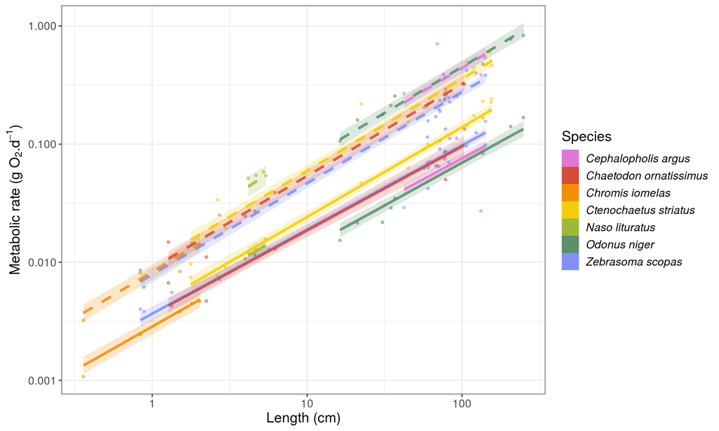

The confidence interval at 95% of SMR predictions on the individual-level is estimated between 0.12 and 0.17 g O2 d−1, while the 95% confidence interval of individuals’ MMR predictions is defined between 0.52 and 0.74 g O2 d−1 across all studied species and size classes.

### Swimming speed predictions

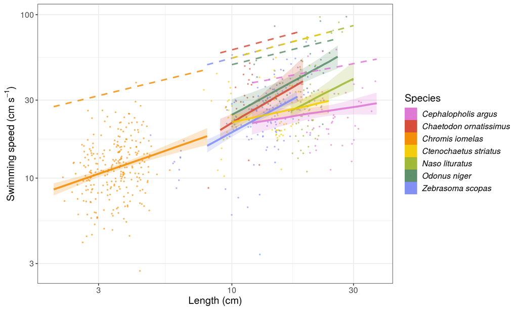

Figure 3. Linear regressions between logarithm-transformed speed (cm s−1) and length (cm) for the 7 studied fish species. Dots are length and swimming speed of individuals measured through stereovideo analysis. Solid lines and grey areas represent the mean values, and associated 95% confidence interval, of swimming speeds predicted by a model for each species .

At the individual scale, the 95% confidence interval of swimming speed predictions varies between 28.5 and 32.4 cm s−1 across all studied species and all size classes.

### Maximum swimming speed predictions

Fulton et al. (2007) estimated maximum swimming speed of several reef fish families with a flow chamber. Using those data, we applied a Bayesian model (model 3) to estimate maximum swimming speed of the fish from our study according to their body size and family identity.

### Field metabolic rate, factorial aerobic scope and factorial activity scope estimations

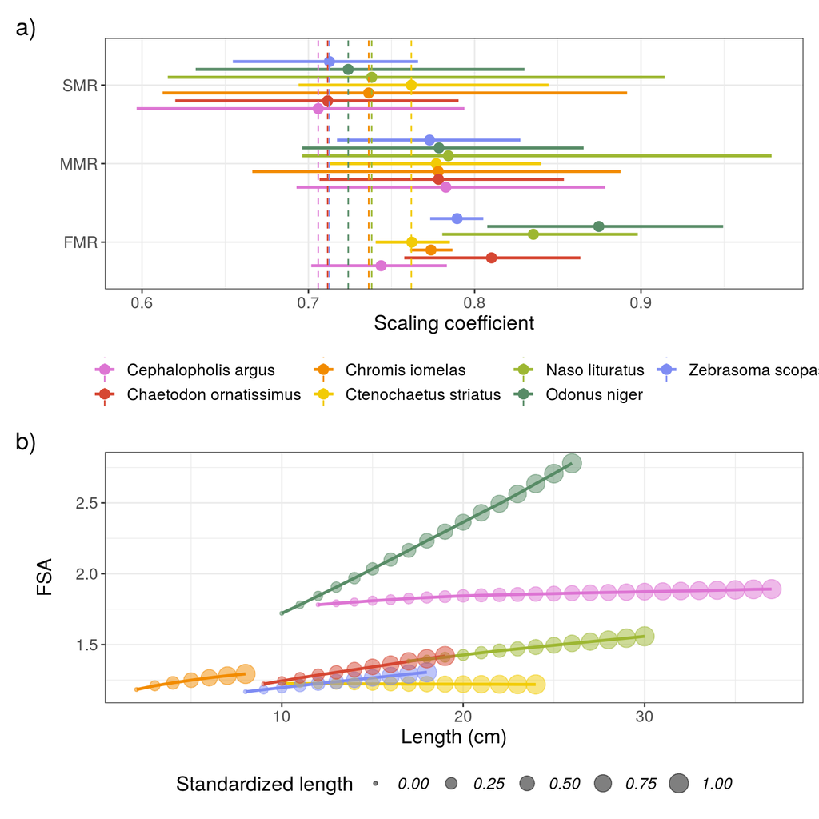

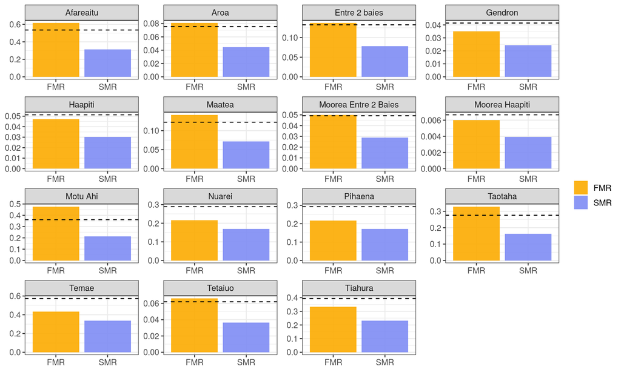

Afareaitu, Maatea, Motu Ahi, Taotaha and Tetaiuo have a total FMR about twice as high as the total SMR, and these are sites where C. argus and O. niger constitutes dominate the reef fish assemblage. On the contrary, sites dominated by C. striatus (50 to 95% of the total reef fish abundance) have a total FMR 1.27 to 1.41 times higher than the total SMR (i.e. Nuarei, Pihaena, Temae, Tiahura). Do we quantify the metabolic scaling coefficient of FMR ifo biomass? Can be an extra thing to add to the results/discussion..

## Discussion

Metabolic rates of our study species vary predictably with body mass, in accordance with the MTE (Brown et al., 2004). The dependence of metabolic rates on body size is demonstrated in many studies and our results add to the existing literature (Schmidt-Nielsen, 1990; White and Seymour, 2003, 2004). The average slope value of our model describing this relationship is equal to the allometric exponent of 0.75 predicted by the model built by West et al. (1997) on the allometric scaling law. Moreover, the range of our FAcS estimations includes the estimates of Trudel and Boisclar (1996) that showed that the average FMR of dace is 1.9 times SMR using both bioenergetic and behaviour approaches. However, other studies quantified FMR up to three to five-fold than SMR in some fish species, and up to nine-fold in tunas (Brill and Bushnell, 1991; Chabot et al., 2016).

Both the swimming speed and the aerobic capacity of fishes affect their field metabolic rate and thus their factorial activity scope (Clark et al. 2013). In our case study, the two fishes with the highest factorial activity scope are O. niger and C. argus, due to their high aerobic scope. They use about one third of their aerobic capacity in their natural environment. On the other hand, fishes with a low factorial activity scope (i.e. C. iomelas, C. ornatissimus, C. striatus, and Z. scopas) are more active, relative to their maximum swimming capacities. Therefore, their factorial activity scope is closer to their factorial aerobic scope.

The interspecific variability of swimming speed, aerobic capacity, and the field metabolic rate in fishes is influenced by ecological traits, such as size, trophic level and habitat use. Small fishes tend to be less performant than bigger ones (Brown et al. 2004). Further, larger sizes in fishes provide physiological advantages, such as swimming abilities permitting the exploitation of larger home ranges (Nash et al., 2015). Furthermore, predators tend to have a higher metabolic capacity, compared to herbivores, and pelagic fishes than benthic fishes, as both have high locomotory demands because of their mobility in a 3D environment (Killen et al., 2016; Nash et al., 2015).

Some limitations have to be considered. Firstly, we used family-level maximum swimming speeds to reconstruct the relationship between metabolic rate and swimming speed. This may introduce some bias into the calculations, as different species were used in Fulton et al. (2007). For all our studied species, maximum swimming speeds should ideally be measured using the critical swimming speed protocol in respirometry (Brett, 1964).  
Further, we assumed that SMR is correlated with MMR by a physiological linkage, FAeS being constant independently of body size (Hayes and Garland, 1995). Many studies found no relationship between FAeS and body size within species (Cutts et al., 2002; Wieser and Forstner, 1986), but others reported FAeS variation according to the mass (Killen et al., 2007). Divergent results across studies can be explained by the variety of studied size ranges. Here, FAeS was estimated on adult reef fishes, contrary to Killen et al. (2007) who measured SMR and MMR of fish larvae. However, more work is needed to disentangle the relationship between FAeS and body size. Finally, we quantified FAcS assuming that fishes’ spontaneous swimming varies at the daily scale with nocturnal resting periods. However, there are day-active as well as night-active species of fish (Zhdanova and Reebs, 2006). All our studied families are diurnal families, except for Serranidae (Hobson, 1965). In fact, groupers can be nocturnally active (Mourier et al., 2016). Thus, our assumption can cause potential underestimations of FAcS in C. argus. Our stereo-video recordings are unadapted to quantify fish swimming speeds during the night, as measurements are inaccurate and imprecise with the darkness and bad visibility (Neuswanger et al., 2016). Infrared lighting in stereo-video recordings could be used to observe nocturnal behaviour and movements in fishes (Bassett and Montgomery, 2011).

Despite these few limitations, our proposed method may help fill the knowledge gap on field metabolic rates in fishes. Data is scarce because it is challenging to observe the fishes in the field. Laboratory techniques have been developed and used to quantify FMR, however they are generally destructives or biased (Chung et al., 2019; Treberg et al., 2016). The development of open-source software to analyze videos demands a high sampling effort but provides the possibility to quantitatively measure activity of fishes in their environment. Thanks to the accuracy and the non-destructive nature of stereo-video techniques, fish activity and behaviour are more and more studied accurately in their natural environment (Bassett and Montgomery, 2011; Boisclair and Sirois, 1993; Guénard et al., 2008).

Anthropogenic stressors such as overfishing and climate change are affecting fish communities at an unprecedented scale. In recent times, the concern is growing that impoverished fish communities may not be able to sustain ecosystem functioning and provide the ecosystem services that are indispensable for human well-being. In order to take the pulse of the functioning of a community, it is essential to quantify key ecosystem processes such as nutrient cycling, herbivory, predation, growth, etc (Brandl et al. 2019). The metabolic rate is an essential component to estimate all of these processes. As the activity scope is an important determinant of the field metabolic rate, we need more research in order to study the role of fish in ecosystem functioning.